# Problema 4 - Checkpoint 1

## Dados de commits no github

Neste relatório vamos responder duas perguntas através de uma amostra de dados da atividade global do github. Inicialmente temos que escolher duas linguagens de programação para responder as perguntas, no caso eu escolhi as linguagens **JAVA** e **C**.

```r
dados = read_csv(file = "./dados/github.csv")

dados$date <- paste(dados$month_day, dados$the_month, dados$the_year, sep = "-")

java <- dados %>%
  filter(file_extension == 'java') %>%
  mutate(weekday = weekdays(as.Date(date,'%d-%m-%Y')))

c <- dados %>%
  filter(file_extension == 'c') %>%
  mutate(weekday = weekdays(as.Date(date,'%d-%m-%Y')))
```

### JAVA

De modo geral, a linguagem de programação JAVA parece ser bastante popular, tanto no meio acadêmico quanto no ambiente corporativo. No gráfico abaixo vamos oberservar como se comporta os dados da nossa amostra com relação a popularidade dessa linguagem durante todos os dias da semana.

```r
p = java %>%
  ggplot(aes(x = weekday,
             y = users)) +
  geom_boxplot(outlier.colour = NA) +
  geom_point(aes(text = paste("Dia da semana:", weekday, "<br>", "Popularidade:", users)),
             position = position_jitter(width = .2),
             alpha = .6,
             color = "blue") +
  labs(title = "Popularidade da linguagem JAVA",
         x = "Dia da semana",
         y = "Popularidade")

ggplotly(p, tooltip = "text")
```

[interactive chart not shown]

Podemos observar que a popularidade da linguagem JAVA varia, de modo geral, aproximadamente num intervalo de 1100 a 4500 usuários por dia. Onde esses valores costumam ser menores durante os finais de semana. No gráfico acima, ainda podemos verificar a existência de *outliers* em todos os dias, que representam valores com um grande afastamento dos demais valores.

### C

A linguagem de programção C é menos popular que JAVA, como já podíamos imaginar. No gráfico abaixo vamos oberservar como se comporta os dados da nossa amostra com relação a popularidade dessa linguagem durante todos os dias da semana.

```r
p = c %>%
  ggplot(aes(x = weekday,
             y = users)) +
  geom_boxplot(outlier.colour = NA) +
  geom_point(aes(text = paste("Dia da semana:", weekday, "<br>", "Popularidade:", users)),
             position = position_jitter(width = .2),
             alpha = .6,
             color = "blue") +
  labs(title = "Popularidade da linguagem C",
         x = "Dia da semana",
         y = "Popularidade")

ggplotly(p, tooltip = "text")
```

[interactive chart not shown]

De modo geral, podemos observar que a popularidade da linguagem de programação C varia num intervalo bem menor que o da linguagem JAVA, aproximadamente num intervalo de 500 a 1900 usuários por dia. Onde esses valores também costumam ser menores durante os finais de semana. No gráfico acima, ainda podemos verificar a existência de *outliers* em todos os dias, exceto nos domingos, que representam valores com um grande afastamento dos demais valores.

### Pergunta 1

**Para cada uma delas, há uma diferença significativa na sua popularidade durante a semana e durante o fim de semana? Essa diferença é grande?**

**Diferença entre a popularidade de usuários durante os dias de semana e nos finais de semana (JAVA)**

```r
java_semana <- java %>%
  filter(weekday != 'sábado', weekday != 'domingo') %>%
  mutate(is_fds = FALSE)

java_fds <- java %>%
  filter(weekday == 'sábado'| weekday == 'domingo') %>%
  mutate(is_fds = TRUE)

java_merge <- rbind(java_semana, java_fds)

res.boot <- boot(data = java_merge, statistic = fun.boot, R = 2000)

boot.ci(boot.out = res.boot, conf = 0.95, type = "bca")
```

```
## BOOTSTRAP CONFIDENCE INTERVAL CALCULATIONS
## Based on 2000 bootstrap replicates
##
## CALL :
## boot.ci(boot.out = res.boot, conf = 0.95, type = "bca")
##
## Intervals :
## Level       BCa
## 95%   ( 1.648,  1.758 )
## Calculations and Intervals on Original Scale
```

**Diferença entre a popularidade de usuários durante os dias de semana e nos finais de semana (C)**

```
## BOOTSTRAP CONFIDENCE INTERVAL CALCULATIONS
## Based on 2000 bootstrap replicates
##
## CALL :
## boot.ci(boot.out = res.boot, conf = 0.95, type = "bca")
##
## Intervals :
## Level       BCa
## 95%   ( 1.560,  1.669 )
## Calculations and Intervals on Original Scale
```

### Pergunta 2

**Existe uma diferença significativa entre as duas linguagens na sua variação de popularidade nos finais de semana?**

Neste caso, vamos investigar duas amostras diferentes, ou seja, não pareadas. Vamos utilizar a técnica bootstrap e em seguida determinar o intervalo de confiança para a diferença na variação das atividades no github entre os programadores das linguagens Java e C durante os fins de semana.  
Para responder essa pergunta vamos utilizar a medida estatística desvio padrão, portanto o que nos interessa é obter o desvio padrão da popularidade de cada uma das linguagens (Java e C) durante o fim de semana.

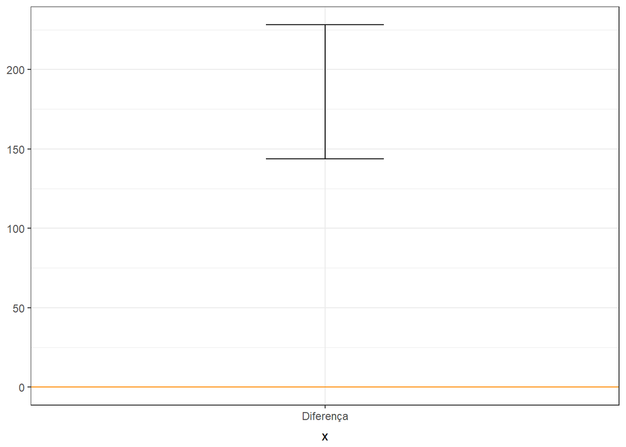

```r
b <- bootstrap2(data = (java_fds)$users,
               data2 = (c_fds)$users,
               sd)

b.ci = CI.percentile(b, probs = c(.025, .975))

data.frame(b.ci) %>%
  ggplot(aes(x = "Diferença", ymin = X2.5., ymax = X97.5.)) +
  geom_errorbar(width = .2) +
  geom_hline(yintercept = 0, colour = "darkorange")
```

Podemos afirmar com 95% de confiança que a diferença do desvio padrão está no intervalo (143.7349388, 228.1560801). Logo, ainda é possível afirmarmos que a variação da popularidade durante os finais de semana é maior para a linguagem de progamação Java.